# Risk Factor Analysis

## Outcome Variable

**Outcome Variable:** ever_swasted

## Predictor Variables

**Intervention Variable:** parity

**Adjustment Set:**

- arm
- W_mage
- meducyrs
- feducyrs
- hhwealth_quart
- W_mhtcm
- vagbrth
- W_nrooms
- impsan
- delta_W_mage
- delta_meducyrs
- delta_feducyrs
- delta_hhwealth_quart
- delta_W_mhtcm
- delta_vagbrth
- delta_W_nrooms
- delta_impsan

## Stratifying Variables

The analysis was stratified on these variable(s):

- agecat
- studyid
- country

## Data Summary

| agecat | studyid | country | parity | ever_swasted | n_cell | n |
| --- | --- | --- | --- | --- | --- | --- |
| 0-24 months | ki1000304b-SAS-CompFeed | INDIA | 1 | 0 | 400 | 1513 |
| 0-24 months | ki1000304b-SAS-CompFeed | INDIA | 1 | 1 | 48 | 1513 |
| 0-24 months | ki1000304b-SAS-CompFeed | INDIA | 2 | 0 | 300 | 1513 |
| 0-24 months | ki1000304b-SAS-CompFeed | INDIA | 2 | 1 | 54 | 1513 |
| 0-24 months | ki1000304b-SAS-CompFeed | INDIA | 3+ | 0 | 590 | 1513 |
| 0-24 months | ki1000304b-SAS-CompFeed | INDIA | 3+ | 1 | 121 | 1513 |
| 0-24 months | ki1000304b-SAS-FoodSuppl | INDIA | 1 | 0 | 70 | 397 |
| 0-24 months | ki1000304b-SAS-FoodSuppl | INDIA | 1 | 1 | 7 | 397 |
| 0-24 months | ki1000304b-SAS-FoodSuppl | INDIA | 2 | 0 | 79 | 397 |
| 0-24 months | ki1000304b-SAS-FoodSuppl | INDIA | 2 | 1 | 13 | 397 |
| 0-24 months | ki1000304b-SAS-FoodSuppl | INDIA | 3+ | 0 | 181 | 397 |
| 0-24 months | ki1000304b-SAS-FoodSuppl | INDIA | 3+ | 1 | 47 | 397 |
| 0-24 months | ki1017093b-PROVIDE | BANGLADESH | 1 | 0 | 252 | 700 |
| 0-24 months | ki1017093b-PROVIDE | BANGLADESH | 1 | 1 | 19 | 700 |
| 0-24 months | ki1017093b-PROVIDE | BANGLADESH | 2 | 0 | 236 | 700 |
| 0-24 months | ki1017093b-PROVIDE | BANGLADESH | 2 | 1 | 8 | 700 |
| 0-24 months | ki1017093b-PROVIDE | BANGLADESH | 3+ | 0 | 170 | 700 |
| 0-24 months | ki1017093b-PROVIDE | BANGLADESH | 3+ | 1 | 15 | 700 |
| 0-24 months | ki1066203-TanzaniaChild2 | TANZANIA, UNITED REPUBLIC OF | 1 | 0 | 767 | 2357 |
| 0-24 months | ki1066203-TanzaniaChild2 | TANZANIA, UNITED REPUBLIC OF | 1 | 1 | 54 | 2357 |
| 0-24 months | ki1066203-TanzaniaChild2 | TANZANIA, UNITED REPUBLIC OF | 2 | 0 | 717 | 2357 |
| 0-24 months | ki1066203-TanzaniaChild2 | TANZANIA, UNITED REPUBLIC OF | 2 | 1 | 54 | 2357 |
| 0-24 months | ki1066203-TanzaniaChild2 | TANZANIA, UNITED REPUBLIC OF | 3+ | 0 | 716 | 2357 |
| 0-24 months | ki1066203-TanzaniaChild2 | TANZANIA, UNITED REPUBLIC OF | 3+ | 1 | 49 | 2357 |
| 0-24 months | ki1101329-Keneba | GAMBIA | 1 | 0 | 208 | 1989 |
| 0-24 months | ki1101329-Keneba | GAMBIA | 1 | 1 | 32 | 1989 |
| 0-24 months | ki1101329-Keneba | GAMBIA | 2 | 0 | 184 | 1989 |
| 0-24 months | ki1101329-Keneba | GAMBIA | 2 | 1 | 30 | 1989 |
| 0-24 months | ki1101329-Keneba | GAMBIA | 3+ | 0 | 1279 | 1989 |
| 0-24 months | ki1101329-Keneba | GAMBIA | 3+ | 1 | 256 | 1989 |

[output cut: 168 more lines]

The following strata were considered:

- agecat: 0-24 months, studyid: ki1000304b-SAS-CompFeed, country: INDIA
- agecat: 0-24 months, studyid: ki1000304b-SAS-FoodSuppl, country: INDIA
- agecat: 0-24 months, studyid: ki1017093b-PROVIDE, country: BANGLADESH
- agecat: 0-24 months, studyid: ki1066203-TanzaniaChild2, country: TANZANIA, UNITED REPUBLIC OF
- agecat: 0-24 months, studyid: ki1101329-Keneba, country: GAMBIA
- agecat: 0-24 months, studyid: ki1113344-GMS-Nepal, country: NEPAL
- agecat: 0-24 months, studyid: ki1126311-ZVITAMBO, country: ZIMBABWE
- agecat: 0-24 months, studyid: ki1135781-COHORTS, country: GUATEMALA
- agecat: 0-24 months, studyid: ki1135781-COHORTS, country: INDIA
- agecat: 0-24 months, studyid: ki1135781-COHORTS, country: PHILIPPINES
- agecat: 0-24 months, studyid: kiGH5241-JiVitA-3, country: BANGLADESH
- agecat: 0-6 months, studyid: ki1000304b-SAS-CompFeed, country: INDIA
- agecat: 0-6 months, studyid: ki1000304b-SAS-FoodSuppl, country: INDIA
- agecat: 0-6 months, studyid: ki1017093b-PROVIDE, country: BANGLADESH
- agecat: 0-6 months, studyid: ki1066203-TanzaniaChild2, country: TANZANIA, UNITED REPUBLIC OF
- agecat: 0-6 months, studyid: ki1101329-Keneba, country: GAMBIA
- agecat: 0-6 months, studyid: ki1113344-GMS-Nepal, country: NEPAL
- agecat: 0-6 months, studyid: ki1126311-ZVITAMBO, country: ZIMBABWE
- agecat: 0-6 months, studyid: ki1135781-COHORTS, country: GUATEMALA
- agecat: 0-6 months, studyid: ki1135781-COHORTS, country: INDIA
- agecat: 0-6 months, studyid: ki1135781-COHORTS, country: PHILIPPINES
- agecat: 0-6 months, studyid: kiGH5241-JiVitA-3, country: BANGLADESH
- agecat: 6-24 months, studyid: ki1000304b-SAS-CompFeed, country: INDIA
- agecat: 6-24 months, studyid: ki1000304b-SAS-FoodSuppl, country: INDIA
- agecat: 6-24 months, studyid: ki1017093b-PROVIDE, country: BANGLADESH
- agecat: 6-24 months, studyid: ki1066203-TanzaniaChild2, country: TANZANIA, UNITED REPUBLIC OF
- agecat: 6-24 months, studyid: ki1101329-Keneba, country: GAMBIA
- agecat: 6-24 months, studyid: ki1113344-GMS-Nepal, country: NEPAL
- agecat: 6-24 months, studyid: ki1126311-ZVITAMBO, country: ZIMBABWE
- agecat: 6-24 months, studyid: ki1135781-COHORTS, country: GUATEMALA
- agecat: 6-24 months, studyid: ki1135781-COHORTS, country: INDIA
- agecat: 6-24 months, studyid: ki1135781-COHORTS, country: PHILIPPINES
- agecat: 6-24 months, studyid: kiGH5241-JiVitA-3, country: BANGLADESH

### Dropped Strata

Some strata were dropped due to rare outcomes:

- agecat: 0-6 months, studyid: ki1000304b-SAS-FoodSuppl, country: INDIA
- agecat: 0-6 months, studyid: ki1017093b-PROVIDE, country: BANGLADESH
- agecat: 6-24 months, studyid: ki1017093b-PROVIDE, country: BANGLADESH

## Methods Detail

We’re interested in the causal parameters $E[Y_a]$ for all values of $a \in \mathcal{A}$. These parameters represent the mean outcome if, possibly contrary to fact, we intervened to set all units to have $A=a$. Under the randomization and positivity assumptions, these are identified by the statistical parameters $\psi_a=E_W[E_{Y|A,W}(Y|A=a,W)]$. In addition, we’re interested in the mean of $Y$, $E[Y]$ under no intervention (the observed mean). We will estimate these parameters by using SuperLearner to fit the relevant likelihood factors – $E_{Y|A,W}(Y|A=a,W)$ and $p(A=a|W)$, and then updating our likelihood fit using a joint TMLE.

For unadjusted analyses ($W=\{\}$), initial likelihoods were estimated using Lrnr_glm to estimate the simple $E(Y|A)$ and Lrnr_mean to estimate $p(A)$. For adjusted analyses, a small library containing Lrnr_glmnet, Lrnr_xgboost, and Lrnr_mean was used.

Having estimated these parameters, we will then use the delta method to estimate relative risks and attributable risks relative to a prespecified baseline level of $A$.

# Results Detail

## Results Plots

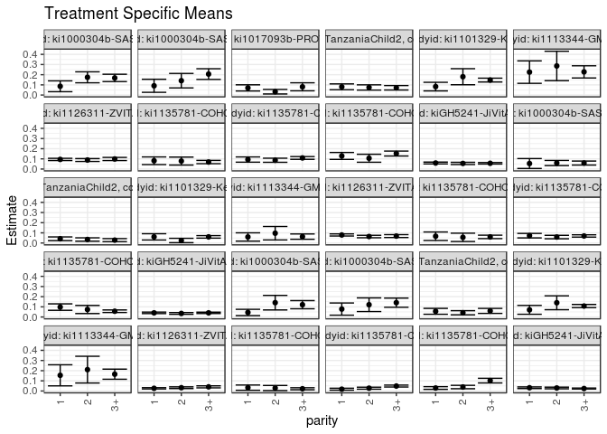

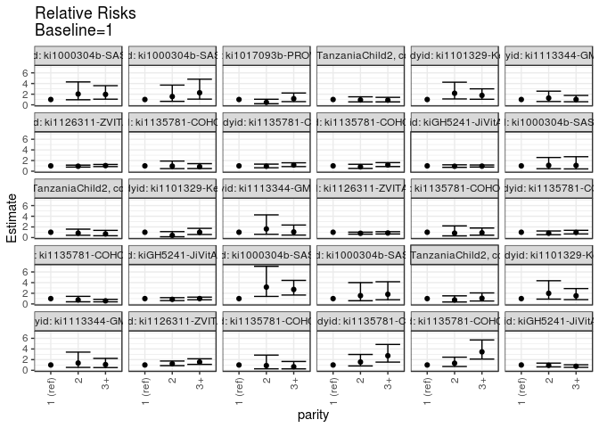

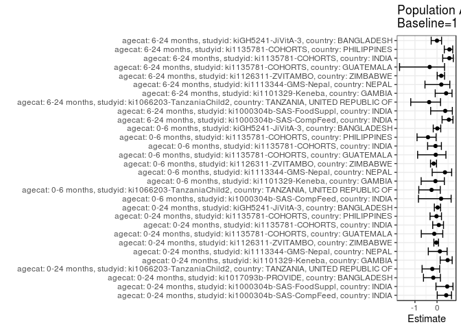

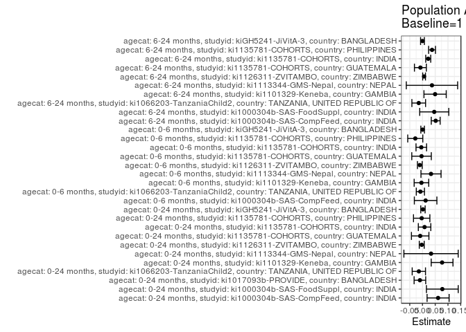

## Results Table

### Parameter: TSM

| agecat | studyid | country | intervention_level | baseline_level | estimate | ci_lower | ci_upper |
| --- | --- | --- | --- | --- | --- | --- | --- |
| 0-24 months | ki1000304b-SAS-CompFeed | INDIA | 1 | NA | 0.0861180 | 0.0328826 | 0.1393533 |
| 0-24 months | ki1000304b-SAS-CompFeed | INDIA | 2 | NA | 0.1745396 | 0.1206486 | 0.2284307 |
| 0-24 months | ki1000304b-SAS-CompFeed | INDIA | 3+ | NA | 0.1683977 | 0.1323457 | 0.2044497 |
| 0-24 months | ki1000304b-SAS-FoodSuppl | INDIA | 1 | NA | 0.0909091 | 0.0266170 | 0.1552012 |
| 0-24 months | ki1000304b-SAS-FoodSuppl | INDIA | 2 | NA | 0.1413043 | 0.0700356 | 0.2125731 |
| 0-24 months | ki1000304b-SAS-FoodSuppl | INDIA | 3+ | NA | 0.2061404 | 0.1535651 | 0.2587156 |
| 0-24 months | ki1017093b-PROVIDE | BANGLADESH | 1 | NA | 0.0701107 | 0.0396891 | 0.1005323 |
| 0-24 months | ki1017093b-PROVIDE | BANGLADESH | 2 | NA | 0.0327869 | 0.0104267 | 0.0551470 |
| 0-24 months | ki1017093b-PROVIDE | BANGLADESH | 3+ | NA | 0.0810811 | 0.0417196 | 0.1204425 |
| 0-24 months | ki1066203-TanzaniaChild2 | TANZANIA, UNITED REPUBLIC OF | 1 | NA | 0.0809152 | 0.0523296 | 0.1095008 |
| 0-24 months | ki1066203-TanzaniaChild2 | TANZANIA, UNITED REPUBLIC OF | 2 | NA | 0.0745289 | 0.0488635 | 0.1001944 |
| 0-24 months | ki1066203-TanzaniaChild2 | TANZANIA, UNITED REPUBLIC OF | 3+ | NA | 0.0712816 | 0.0495034 | 0.0930599 |
| 0-24 months | ki1101329-Keneba | GAMBIA | 1 | NA | 0.0829486 | 0.0407523 | 0.1251449 |
| 0-24 months | ki1101329-Keneba | GAMBIA | 2 | NA | 0.1801650 | 0.1011996 | 0.2591305 |
| 0-24 months | ki1101329-Keneba | GAMBIA | 3+ | NA | 0.1472213 | 0.1284155 | 0.1660271 |
| 0-24 months | ki1113344-GMS-Nepal | NEPAL | 1 | NA | 0.2255616 | 0.1150637 | 0.3360594 |
| 0-24 months | ki1113344-GMS-Nepal | NEPAL | 2 | NA | 0.2860340 | 0.1415068 | 0.4305612 |
| 0-24 months | ki1113344-GMS-Nepal | NEPAL | 3+ | NA | 0.2277921 | 0.1679632 | 0.2876210 |
| 0-24 months | ki1126311-ZVITAMBO | ZIMBABWE | 1 | NA | 0.0944983 | 0.0837183 | 0.1052783 |
| 0-24 months | ki1126311-ZVITAMBO | ZIMBABWE | 2 | NA | 0.0885122 | 0.0743859 | 0.1026385 |
| 0-24 months | ki1126311-ZVITAMBO | ZIMBABWE | 3+ | NA | 0.0988514 | 0.0833596 | 0.1143432 |
| 0-24 months | ki1135781-COHORTS | GUATEMALA | 1 | NA | 0.0814013 | 0.0437724 | 0.1190303 |
| 0-24 months | ki1135781-COHORTS | GUATEMALA | 2 | NA | 0.0783915 | 0.0392255 | 0.1175574 |
| 0-24 months | ki1135781-COHORTS | GUATEMALA | 3+ | NA | 0.0686951 | 0.0525620 | 0.0848282 |
| 0-24 months | ki1135781-COHORTS | INDIA | 1 | NA | 0.0932523 | 0.0675502 | 0.1189544 |
| 0-24 months | ki1135781-COHORTS | INDIA | 2 | NA | 0.0863154 | 0.0660932 | 0.1065376 |
| 0-24 months | ki1135781-COHORTS | INDIA | 3+ | NA | 0.1089811 | 0.0955346 | 0.1224276 |
| 0-24 months | ki1135781-COHORTS | PHILIPPINES | 1 | NA | 0.1286039 | 0.0945158 | 0.1626920 |
| 0-24 months | ki1135781-COHORTS | PHILIPPINES | 2 | NA | 0.1061557 | 0.0669497 | 0.1453617 |
| 0-24 months | ki1135781-COHORTS | PHILIPPINES | 3+ | NA | 0.1523901 | 0.1280975 | 0.1766827 |

[output cut: 60 more lines]

### Parameter: E(Y)

| agecat | studyid | country | intervention_level | baseline_level | estimate | ci_lower | ci_upper |
| --- | --- | --- | --- | --- | --- | --- | --- |
| 0-24 months | ki1000304b-SAS-CompFeed | INDIA | NA | NA | 0.1473893 | 0.1184132 | 0.1763654 |
| 0-24 months | ki1000304b-SAS-FoodSuppl | INDIA | NA | NA | 0.1687657 | 0.1318761 | 0.2056554 |
| 0-24 months | ki1017093b-PROVIDE | BANGLADESH | NA | NA | 0.0600000 | 0.0423945 | 0.0776055 |
| 0-24 months | ki1066203-TanzaniaChild2 | TANZANIA, UNITED REPUBLIC OF | NA | NA | 0.0666101 | 0.0565417 | 0.0766785 |
| 0-24 months | ki1101329-Keneba | GAMBIA | NA | NA | 0.1598793 | 0.1437689 | 0.1759898 |
| 0-24 months | ki1113344-GMS-Nepal | NEPAL | NA | NA | 0.2591362 | 0.2241059 | 0.2941665 |
| 0-24 months | ki1126311-ZVITAMBO | ZIMBABWE | NA | NA | 0.0915483 | 0.0867604 | 0.0963361 |
| 0-24 months | ki1135781-COHORTS | GUATEMALA | NA | NA | 0.0723341 | 0.0584645 | 0.0862036 |
| 0-24 months | ki1135781-COHORTS | INDIA | NA | NA | 0.1014273 | 0.0927249 | 0.1101298 |
| 0-24 months | ki1135781-COHORTS | PHILIPPINES | NA | NA | 0.1254516 | 0.1136848 | 0.1372183 |
| 0-24 months | kiGH5241-JiVitA-3 | BANGLADESH | NA | NA | 0.0609616 | 0.0574870 | 0.0644361 |
| 0-6 months | ki1000304b-SAS-CompFeed | INDIA | NA | NA | 0.0664452 | 0.0425975 | 0.0902929 |
| 0-6 months | ki1066203-TanzaniaChild2 | TANZANIA, UNITED REPUBLIC OF | NA | NA | 0.0335172 | 0.0262496 | 0.0407848 |
| 0-6 months | ki1101329-Keneba | GAMBIA | NA | NA | 0.0565313 | 0.0459241 | 0.0671385 |
| 0-6 months | ki1113344-GMS-Nepal | NEPAL | NA | NA | 0.0930233 | 0.0698010 | 0.1162455 |
| 0-6 months | ki1126311-ZVITAMBO | ZIMBABWE | NA | NA | 0.0686841 | 0.0644712 | 0.0728970 |
| 0-6 months | ki1135781-COHORTS | GUATEMALA | NA | NA | 0.0630292 | 0.0484135 | 0.0776449 |
| 0-6 months | ki1135781-COHORTS | INDIA | NA | NA | 0.0675068 | 0.0601293 | 0.0748842 |
| 0-6 months | ki1135781-COHORTS | PHILIPPINES | NA | NA | 0.0693167 | 0.0602923 | 0.0783411 |
| 0-6 months | kiGH5241-JiVitA-3 | BANGLADESH | NA | NA | 0.0413220 | 0.0383449 | 0.0442991 |
| 6-24 months | ki1000304b-SAS-CompFeed | INDIA | NA | NA | 0.0964723 | 0.0729872 | 0.1199573 |
| 6-24 months | ki1000304b-SAS-FoodSuppl | INDIA | NA | NA | 0.1240506 | 0.0915015 | 0.1565997 |
| 6-24 months | ki1066203-TanzaniaChild2 | TANZANIA, UNITED REPUBLIC OF | NA | NA | 0.0412682 | 0.0325201 | 0.0500164 |
| 6-24 months | ki1101329-Keneba | GAMBIA | NA | NA | 0.1200624 | 0.1055350 | 0.1345898 |
| 6-24 months | ki1113344-GMS-Nepal | NEPAL | NA | NA | 0.1915254 | 0.1597467 | 0.2233042 |
| 6-24 months | ki1126311-ZVITAMBO | ZIMBABWE | NA | NA | 0.0325447 | 0.0291813 | 0.0359080 |
| 6-24 months | ki1135781-COHORTS | GUATEMALA | NA | NA | 0.0247321 | 0.0159885 | 0.0334756 |
| 6-24 months | ki1135781-COHORTS | INDIA | NA | NA | 0.0403319 | 0.0344774 | 0.0461863 |
| 6-24 months | ki1135781-COHORTS | PHILIPPINES | NA | NA | 0.0669277 | 0.0576848 | 0.0761707 |
| 6-24 months | kiGH5241-JiVitA-3 | BANGLADESH | NA | NA | 0.0319278 | 0.0290347 | 0.0348209 |

### Parameter: RR

| agecat | studyid | country | intervention_level | baseline_level | estimate | ci_lower | ci_upper |
| --- | --- | --- | --- | --- | --- | --- | --- |
| 0-24 months | ki1000304b-SAS-CompFeed | INDIA | 1 | 1 | 1.0000000 | 1.0000000 | 1.0000000 |
| 0-24 months | ki1000304b-SAS-CompFeed | INDIA | 2 | 1 | 2.0267510 | 0.9549265 | 4.3016079 |
| 0-24 months | ki1000304b-SAS-CompFeed | INDIA | 3+ | 1 | 1.9554305 | 1.0640667 | 3.5934859 |
| 0-24 months | ki1000304b-SAS-FoodSuppl | INDIA | 1 | 1 | 1.0000000 | 1.0000000 | 1.0000000 |
| 0-24 months | ki1000304b-SAS-FoodSuppl | INDIA | 2 | 1 | 1.5543477 | 0.6520835 | 3.7050420 |
| 0-24 months | ki1000304b-SAS-FoodSuppl | INDIA | 3+ | 1 | 2.2675436 | 1.0691885 | 4.8090249 |
| 0-24 months | ki1017093b-PROVIDE | BANGLADESH | 1 | 1 | 1.0000000 | 1.0000000 | 1.0000000 |
| 0-24 months | ki1017093b-PROVIDE | BANGLADESH | 2 | 1 | 0.4676445 | 0.2083855 | 1.0494558 |
| 0-24 months | ki1017093b-PROVIDE | BANGLADESH | 3+ | 1 | 1.1564723 | 0.6030613 | 2.2177317 |
| 0-24 months | ki1066203-TanzaniaChild2 | TANZANIA, UNITED REPUBLIC OF | 1 | 1 | 1.0000000 | 1.0000000 | 1.0000000 |
| 0-24 months | ki1066203-TanzaniaChild2 | TANZANIA, UNITED REPUBLIC OF | 2 | 1 | 0.9210745 | 0.5627861 | 1.5074612 |
| 0-24 months | ki1066203-TanzaniaChild2 | TANZANIA, UNITED REPUBLIC OF | 3+ | 1 | 0.8809426 | 0.5520612 | 1.4057496 |
| 0-24 months | ki1101329-Keneba | GAMBIA | 1 | 1 | 1.0000000 | 1.0000000 | 1.0000000 |
| 0-24 months | ki1101329-Keneba | GAMBIA | 2 | 1 | 2.1720081 | 1.1091350 | 4.2534222 |
| 0-24 months | ki1101329-Keneba | GAMBIA | 3+ | 1 | 1.7748500 | 1.0500691 | 2.9998907 |
| 0-24 months | ki1113344-GMS-Nepal | NEPAL | 1 | 1 | 1.0000000 | 1.0000000 | 1.0000000 |
| 0-24 months | ki1113344-GMS-Nepal | NEPAL | 2 | 1 | 1.2680974 | 0.6273020 | 2.5634717 |
| 0-24 months | ki1113344-GMS-Nepal | NEPAL | 3+ | 1 | 1.0098889 | 0.5794058 | 1.7602094 |
| 0-24 months | ki1126311-ZVITAMBO | ZIMBABWE | 1 | 1 | 1.0000000 | 1.0000000 | 1.0000000 |
| 0-24 months | ki1126311-ZVITAMBO | ZIMBABWE | 2 | 1 | 0.9366534 | 0.7698041 | 1.1396661 |
| 0-24 months | ki1126311-ZVITAMBO | ZIMBABWE | 3+ | 1 | 1.0460653 | 0.8617345 | 1.2698256 |
| 0-24 months | ki1135781-COHORTS | GUATEMALA | 1 | 1 | 1.0000000 | 1.0000000 | 1.0000000 |
| 0-24 months | ki1135781-COHORTS | GUATEMALA | 2 | 1 | 0.9630246 | 0.4875401 | 1.9022359 |
| 0-24 months | ki1135781-COHORTS | GUATEMALA | 3+ | 1 | 0.8439062 | 0.5024757 | 1.4173374 |
| 0-24 months | ki1135781-COHORTS | INDIA | 1 | 1 | 1.0000000 | 1.0000000 | 1.0000000 |
| 0-24 months | ki1135781-COHORTS | INDIA | 2 | 1 | 0.9256117 | 0.6448246 | 1.3286667 |
| 0-24 months | ki1135781-COHORTS | INDIA | 3+ | 1 | 1.1686695 | 0.8640379 | 1.5807042 |
| 0-24 months | ki1135781-COHORTS | PHILIPPINES | 1 | 1 | 1.0000000 | 1.0000000 | 1.0000000 |
| 0-24 months | ki1135781-COHORTS | PHILIPPINES | 2 | 1 | 0.8254470 | 0.5239288 | 1.3004873 |
| 0-24 months | ki1135781-COHORTS | PHILIPPINES | 3+ | 1 | 1.1849568 | 0.8698599 | 1.6141938 |

[output cut: 60 more lines]

### Parameter: PAR

| agecat | studyid | country | intervention_level | baseline_level | estimate | ci_lower | ci_upper |
| --- | --- | --- | --- | --- | --- | --- | --- |
| 0-24 months | ki1000304b-SAS-CompFeed | INDIA | 1 | NA | 0.0612713 | 0.0180336 | 0.1045091 |
| 0-24 months | ki1000304b-SAS-FoodSuppl | INDIA | 1 | NA | 0.0778566 | 0.0154795 | 0.1402338 |
| 0-24 months | ki1017093b-PROVIDE | BANGLADESH | 1 | NA | -0.0101107 | -0.0328889 | 0.0126675 |
| 0-24 months | ki1066203-TanzaniaChild2 | TANZANIA, UNITED REPUBLIC OF | 1 | NA | -0.0143051 | -0.0404145 | 0.0118043 |
| 0-24 months | ki1101329-Keneba | GAMBIA | 1 | NA | 0.0769307 | 0.0342150 | 0.1196464 |
| 0-24 months | ki1113344-GMS-Nepal | NEPAL | 1 | NA | 0.0335747 | -0.0729693 | 0.1401186 |
| 0-24 months | ki1126311-ZVITAMBO | ZIMBABWE | 1 | NA | -0.0029501 | -0.0125808 | 0.0066807 |
| 0-24 months | ki1135781-COHORTS | GUATEMALA | 1 | NA | -0.0090673 | -0.0433271 | 0.0251926 |
| 0-24 months | ki1135781-COHORTS | INDIA | 1 | NA | 0.0081750 | -0.0163409 | 0.0326910 |
| 0-24 months | ki1135781-COHORTS | PHILIPPINES | 1 | NA | -0.0031523 | -0.0352940 | 0.0289893 |
| 0-24 months | kiGH5241-JiVitA-3 | BANGLADESH | 1 | NA | 0.0018204 | -0.0067574 | 0.0103983 |
| 0-6 months | ki1000304b-SAS-CompFeed | INDIA | 1 | NA | 0.0122446 | -0.0320036 | 0.0564928 |
| 0-6 months | ki1066203-TanzaniaChild2 | TANZANIA, UNITED REPUBLIC OF | 1 | NA | -0.0082970 | -0.0243162 | 0.0077221 |
| 0-6 months | ki1101329-Keneba | GAMBIA | 1 | NA | -0.0040748 | -0.0327035 | 0.0245540 |
| 0-6 months | ki1113344-GMS-Nepal | NEPAL | 1 | NA | 0.0334454 | -0.0059888 | 0.0728796 |
| 0-6 months | ki1126311-ZVITAMBO | ZIMBABWE | 1 | NA | -0.0104131 | -0.0196847 | -0.0011415 |
| 0-6 months | ki1135781-COHORTS | GUATEMALA | 1 | NA | -0.0037497 | -0.0420421 | 0.0345428 |
| 0-6 months | ki1135781-COHORTS | INDIA | 1 | NA | -0.0046841 | -0.0254236 | 0.0160555 |
| 0-6 months | ki1135781-COHORTS | PHILIPPINES | 1 | NA | -0.0283484 | -0.0579100 | 0.0012132 |
| 0-6 months | kiGH5241-JiVitA-3 | BANGLADESH | 1 | NA | 0.0005296 | -0.0064643 | 0.0075234 |
| 6-24 months | ki1000304b-SAS-CompFeed | INDIA | 1 | NA | 0.0518191 | 0.0344136 | 0.0692245 |
| 6-24 months | ki1000304b-SAS-FoodSuppl | INDIA | 1 | NA | 0.0461286 | -0.0108979 | 0.1031550 |
| 6-24 months | ki1066203-TanzaniaChild2 | TANZANIA, UNITED REPUBLIC OF | 1 | NA | -0.0147466 | -0.0416061 | 0.0121129 |
| 6-24 months | ki1101329-Keneba | GAMBIA | 1 | NA | 0.0494626 | 0.0057400 | 0.0931851 |
| 6-24 months | ki1113344-GMS-Nepal | NEPAL | 1 | NA | 0.0371736 | -0.0635990 | 0.1379462 |
| 6-24 months | ki1126311-ZVITAMBO | ZIMBABWE | 1 | NA | 0.0062315 | 0.0007954 | 0.0116676 |
| 6-24 months | ki1135781-COHORTS | GUATEMALA | 1 | NA | -0.0082350 | -0.0316403 | 0.0151703 |
| 6-24 months | ki1135781-COHORTS | INDIA | 1 | NA | 0.0225242 | 0.0127127 | 0.0323357 |
| 6-24 months | ki1135781-COHORTS | PHILIPPINES | 1 | NA | 0.0374793 | 0.0240926 | 0.0508659 |
| 6-24 months | kiGH5241-JiVitA-3 | BANGLADESH | 1 | NA | -0.0000828 | -0.0075326 | 0.0073669 |

### Parameter: PAF

| agecat | studyid | country | intervention_level | baseline_level | estimate | ci_lower | ci_upper |
| --- | --- | --- | --- | --- | --- | --- | --- |
| 0-24 months | ki1000304b-SAS-CompFeed | INDIA | 1 | NA | 0.4157109 | 0.0094460 | 0.6553507 |
| 0-24 months | ki1000304b-SAS-FoodSuppl | INDIA | 1 | NA | 0.4613297 | -0.0483809 | 0.7232249 |
| 0-24 months | ki1017093b-PROVIDE | BANGLADESH | 1 | NA | -0.1685117 | -0.6132761 | 0.1536356 |
| 0-24 months | ki1066203-TanzaniaChild2 | TANZANIA, UNITED REPUBLIC OF | 1 | NA | -0.2147587 | -0.6763111 | 0.1197108 |
| 0-24 months | ki1101329-Keneba | GAMBIA | 1 | NA | 0.4811800 | 0.1423137 | 0.6861624 |
| 0-24 months | ki1113344-GMS-Nepal | NEPAL | 1 | NA | 0.1295638 | -0.3951791 | 0.4569448 |
| 0-24 months | ki1126311-ZVITAMBO | ZIMBABWE | 1 | NA | -0.0322240 | -0.1429738 | 0.0677945 |
| 0-24 months | ki1135781-COHORTS | GUATEMALA | 1 | NA | -0.1253525 | -0.7132530 | 0.2608107 |
| 0-24 months | ki1135781-COHORTS | INDIA | 1 | NA | 0.0806000 | -0.1956469 | 0.2930218 |
| 0-24 months | ki1135781-COHORTS | PHILIPPINES | 1 | NA | -0.0251280 | -0.3162475 | 0.2016035 |
| 0-24 months | kiGH5241-JiVitA-3 | BANGLADESH | 1 | NA | 0.0298620 | -0.1214854 | 0.1607847 |
| 0-6 months | ki1000304b-SAS-CompFeed | INDIA | 1 | NA | 0.1842812 | -0.8418999 | 0.6387442 |
| 0-6 months | ki1066203-TanzaniaChild2 | TANZANIA, UNITED REPUBLIC OF | 1 | NA | -0.2475459 | -0.8259742 | 0.1476491 |
| 0-6 months | ki1101329-Keneba | GAMBIA | 1 | NA | -0.0720800 | -0.7191477 | 0.3314387 |
| 0-6 months | ki1113344-GMS-Nepal | NEPAL | 1 | NA | 0.3595379 | -0.2190498 | 0.6635152 |
| 0-6 months | ki1126311-ZVITAMBO | ZIMBABWE | 1 | NA | -0.1516088 | -0.2947210 | -0.0243155 |
| 0-6 months | ki1135781-COHORTS | GUATEMALA | 1 | NA | -0.0594907 | -0.8788514 | 0.4025495 |
| 0-6 months | ki1135781-COHORTS | INDIA | 1 | NA | -0.0693865 | -0.4253849 | 0.1976992 |
| 0-6 months | ki1135781-COHORTS | PHILIPPINES | 1 | NA | -0.4089694 | -0.9047975 | -0.0422079 |
| 0-6 months | kiGH5241-JiVitA-3 | BANGLADESH | 1 | NA | 0.0128158 | -0.1717275 | 0.1682941 |
| 6-24 months | ki1000304b-SAS-CompFeed | INDIA | 1 | NA | 0.5371395 | 0.2285672 | 0.7222832 |
| 6-24 months | ki1000304b-SAS-FoodSuppl | INDIA | 1 | NA | 0.3718526 | -0.2881157 | 0.6936850 |
| 6-24 months | ki1066203-TanzaniaChild2 | TANZANIA, UNITED REPUBLIC OF | 1 | NA | -0.3573352 | -1.1903304 | 0.1588672 |
| 6-24 months | ki1101329-Keneba | GAMBIA | 1 | NA | 0.4119739 | -0.0819744 | 0.6804225 |
| 6-24 months | ki1113344-GMS-Nepal | NEPAL | 1 | NA | 0.1940923 | -0.5462552 | 0.5799611 |
| 6-24 months | ki1126311-ZVITAMBO | ZIMBABWE | 1 | NA | 0.1914765 | 0.0073875 | 0.3414245 |
| 6-24 months | ki1135781-COHORTS | GUATEMALA | 1 | NA | -0.3329670 | -1.6972387 | 0.3412518 |
| 6-24 months | ki1135781-COHORTS | INDIA | 1 | NA | 0.5584715 | 0.2578705 | 0.7373135 |
| 6-24 months | ki1135781-COHORTS | PHILIPPINES | 1 | NA | 0.5599965 | 0.3292551 | 0.7113611 |
| 6-24 months | kiGH5241-JiVitA-3 | BANGLADESH | 1 | NA | -0.0025936 | -0.2653123 | 0.2055764 |